# Wine data

The data retrieved from (https://archive.ics.uci.edu/ml/datasets/wine) is the results of a chemical analysis of wines grown in the same region in Italy by three different cultivators. There are 13 different measurements taken for different constituents found in the three types of wine.

```python
from sklearn.preprocessing import StandardScaler
from sklearn.model_selection import train_test_split
from sklearn.decomposition import PCA
import matplotlib.pyplot as plt
import pandas as pd
import numpy as np
import warnings
warnings.filterwarnings("ignore")
import packages_and_functions as func
```

### Data Structure

```python
data = pd.read_excel("wine.xlsx")
data.head()
```

|  | Alcohol | Malic_Acid | Ash | Ash_Alcanity | Magnesium | Total_Phenols | Flavanoids | Nonflavanoid_Phenols | Proanthocyanins | Color_Intensity | Hue | OD280 | Proline | Customer_Segment |
| --- | --- | --- | --- | --- | --- | --- | --- | --- | --- | --- | --- | --- | --- | --- |
| 0 | 14.23 | 1.71 | 2.43 | 15.6 | 127 | 2.80 | 3.06 | 0.28 | 2.29 | 5.64 | 1.04 | 3.92 | 1065 | 1 |
| 1 | 13.20 | 1.78 | 2.14 | 11.2 | 100 | 2.65 | 2.76 | 0.26 | 1.28 | 4.38 | 1.05 | 3.40 | 1050 | 1 |
| 2 | 13.16 | 2.36 | 2.67 | 18.6 | 101 | 2.80 | 3.24 | 0.30 | 2.81 | 5.68 | 1.03 | 3.17 | 1185 | 1 |
| 3 | 14.37 | 1.95 | 2.50 | 16.8 | 113 | 3.85 | 3.49 | 0.24 | 2.18 | 7.80 | 0.86 | 3.45 | 1480 | 1 |
| 4 | 13.24 | 2.59 | 2.87 | 21.0 | 118 | 2.80 | 2.69 | 0.39 | 1.82 | 4.32 | 1.04 | 2.93 | 735 | 1 |

## Part1. Original Data

### Data Preprocessing

- Split the data into train and test part
- Standardization

Note: we assume that the test data is invisible, so we standardize test data with mean and std from train data.

```python
X = data.drop('Customer_Segment', axis=1)
y = data['Customer_Segment']
group = np.unique(y)

X_train, X_test, y_train, y_test = train_test_split(X, y, test_size=0.30, random_state = 410878048)


# Standardize the test data by means and std from train data
X_var_mean = np.array(np.mean(X_train, axis = 0)).reshape(1, -1)
X_var_std = np.array(np.std(X_train, axis = 0)).reshape(1, -1)
X_test = (X_test - X_var_mean)/ X_var_std

# Standardize the train data
scaler = StandardScaler()
X_train = scaler.fit_transform(X_train)
```

### Classification Result

```python
datas = [X_train, y_train, X_test, y_test]
CM_LogReg, _ = func.classificationChoice("LogisticReg", group, *datas)
CM_SVM, _ = func.classificationChoice("SVM", group, *datas)
CM_NeuralNetwork, _ = func.classificationChoice("NeuralNetwork", group, *datas)
func.modelResult([CM_LogReg, CM_SVM, CM_NeuralNetwork])
```

|  | Precision(%) Logistic Regression | Precision(%) SVM | Precision(%) NeuralNetwork | Recall(%) Logistic Regression | Recall(%) SVM | Recall(%) NeuralNetwork |
| --- | --- | --- | --- | --- | --- | --- |
| Class 0 | 100.0 | 100.0 | 100.0 | 94.4 | 94.4 | 94.4 |
| Class 1 | 95.5 | 91.3 | 95.5 | 100.0 | 100.0 | 100.0 |
| Class 2 | 100.0 | 100.0 | 100.0 | 100.0 | 93.3 | 100.0 |
| Mean | 98.5 | 97.1 | 98.5 | 98.1 | 95.9 | 98.1 |

## Part2. PCA Data

### Data Preprocessing

- With dimensionality reduction, we retrieve more important variables from original data.

  Then, we check if the classification would be improved
- Retain 5 variables which account for more than 80% variance of original data
- Train test split -> Standization -> PCA

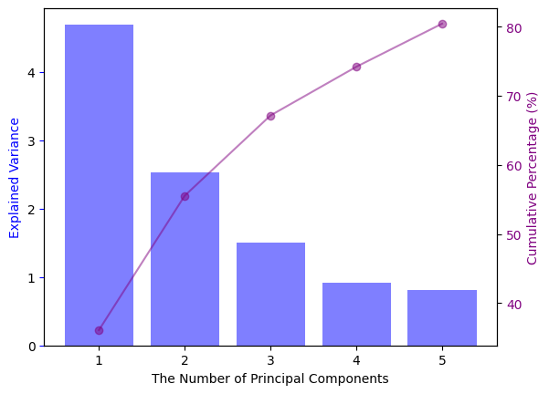

```python
X_train, X_test, y_train, y_test = train_test_split(X, y, test_size=0.30, random_state = 410878048)
# Standardize the test data by means and std from train data
X_var_mean = np.array(np.mean(X_train, axis = 0)).reshape(1, -1)
X_var_std = np.array(np.std(X_train, axis = 0)).reshape(1, -1)
X_test_std = (X_test - X_var_mean)/ X_var_std

# Standardize the train data
scaler = StandardScaler()
X_train_std = scaler.fit_transform(X_train)

pca = PCA()
pca.fit(X_train_std)
# decide the retained number of PCs
cumulative_variances = np.cumsum(pca.explained_variance_)
percentage = [x/X.shape[1] * 100 for x in cumulative_variances]
number_retained = list(np.array(percentage) > 80).count(False) + 1
explained_variance = pca.explained_variance_[:number_retained]
tick_of_pc = [x for x in range(1, len(explained_variance)+1)]

X_train = pca.transform(X_train_std)[:, :number_retained]
X_test = pca.transform(X_test_std)[:, :number_retained]

# show pca result
## plot bar chart
color1 = "blue"
plt.bar(tick_of_pc, explained_variance, color=color1, alpha=0.5)
plt.xlabel('The Number of Principal Components')
plt.ylabel('Explained Variance', color=color1)
plt.tick_params(axis='y', color=color1)
## create secondary y-axis
ax3 = plt.twinx()
## plot cumulative percentage line chart
ax3.plot(tick_of_pc, percentage[:number_retained], color='purple', marker='o', alpha = 0.5)
ax3.set_ylabel('Cumulative Percentage (%)', color='purple')
ax3.tick_params(axis='y', labelcolor='purple')
```

### Classification Result

- This time we try not to tune any parameters.
- In this cases, logistic regression model performs better than SVM, Neural Network model.
- However, the pca data does not appear to better than the original data, which means dimensonality reduction might not be neccessary in this small data.

|  | Precision(%) Logistic Regression | Precision(%) SVM | Precision(%) NeuralNetwork | Recall(%) Logistic Regression | Recall(%) SVM | Recall(%) NeuralNetwork |
| --- | --- | --- | --- | --- | --- | --- |
| Class 0 | 100.0 | 100.0 | 100.0 | 94.4 | 94.4 | 88.9 |
| Class 1 | 95.5 | 91.3 | 87.5 | 100.0 | 100.0 | 100.0 |
| Class 2 | 100.0 | 100.0 | 100.0 | 100.0 | 93.3 | 93.3 |
| Mean | 98.5 | 97.1 | 95.8 | 98.1 | 95.9 | 94.1 |

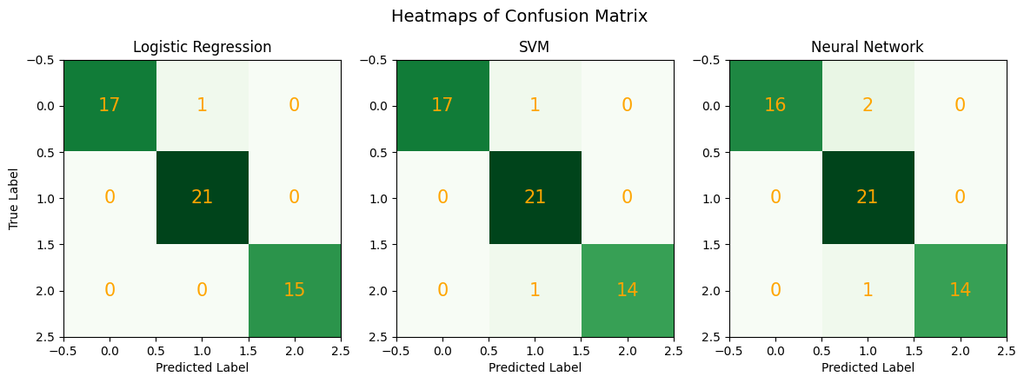

```python
# table
datas = [X_train, y_train, X_test, y_test]
CM_LogReg, pred_LogReg = func.classificationChoice("LogisticReg", group, *datas)
CM_SVM, pred_SVM = func.classificationChoice("SVM", group, *datas)
CM_NeuralNetwork, pred_NN = func.classificationChoice("NeuralNetwork", group, *datas)
display(func.modelResult([CM_LogReg, CM_SVM, CM_NeuralNetwork]))

# Heatmaps of Confusion Matrices
CMs = [CM_LogReg, CM_SVM, CM_NeuralNetwork]
model = ["Logistic Regression", "SVM", "Neural Network"]

# Create a figure with a grid of subplots
fig, axs = plt.subplots(1, len(CMs), figsize=(14, 4.5))

for i, CM in enumerate(CMs):
    # Create a heatmap of the confusion matrix using seaborn
    axs[i].imshow(CM, cmap='Greens')

    # Add text to each cell of the heatmap
    for j in range(CM.shape[0]):
        for k in range(CM.shape[1]):
            text = axs[i].text(k, j, f'{CM[j, k]}', ha='center', va='center', color='Orange', fontsize=15)

    # Add labels for the x and y axes
    axs[i].set_xlabel('Predicted Label')
    axs[0].set_ylabel('True Label')
    axs[i].set_title(f'{model[i]}')
# Add a title for the heatmap
plt.suptitle('Heatmaps of Confusion Matrix', fontsize=14)
plt.show()
```

- On the other hand, using PCA data still has its advantages since we can draw the clustering on the scatter plot. As you see in the below graphs, red data point is misclassfied. Logistic regression model misclassified a case. SVM model misclassified two cases. Neural Network model has three.

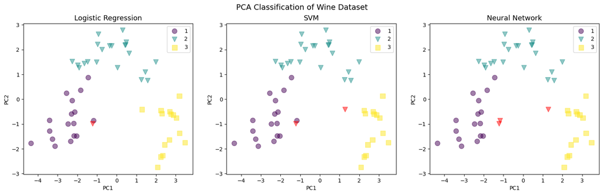

```python
dataset = [pred_LogReg, pred_SVM, pred_NN]
markers = ["o", "v", "s"]
group_distinct = np.unique(y_test)
# 'coolwarm' colormap
coolwarm_colors = plt.get_cmap('viridis')(np.linspace(0, 1, len(group_distinct)))
label_colors = {label: color for label, color in zip(group_distinct, coolwarm_colors)}

# Create a figure and a set of subplots
fig, axs = plt.subplots(1, 3, figsize=(19, 5))
for j, pred_data in enumerate(dataset):
    color_array = np.array([label_colors[x] for x in y_test])
    # label red if misclassification
    color_array[y_test != pred_data] = [1, 0, 0, 1]
    for i in range(len(group_distinct)):
        axs[j].scatter(X_test[pred_data == group_distinct[i], 0], X_test[pred_data == group_distinct[i], 1], c = color_array[pred_data == group_distinct[i]]\
                    , marker = markers[i], alpha=0.5, label = group_distinct[i], s= 80)
    axs[j].legend()
    axs[j].set_xlabel("PC1")
    axs[j].set_ylabel("PC2")
    axs[j].set_title(f"{model[j]}", fontsize=13)
plt.suptitle("PCA Classification of Wine Dataset", fontsize=14)
plt.show()
```